# Intro to the Tidyverse | Becoming Fluent in Data

This book is **Work in Progress**. I appreciate your feedback to make the book better.

## Intro to the Tidyverse

The `tidyverse` is a collection of packages for data science that share a philosophy, a grammar and a set of data structures.[^2] Install it once, load it once per session, and you have `readr` for reading data, `dplyr` for reshaping it, `ggplot2` for drawing it, and a dozen more.

```r
install.packages("tidyverse")   # once per computer
library(tidyverse)              # once per session
```

Loading it prints a short report of which packages came along and which base R functions they have replaced. That is not an error message; it is a receipt.

### Meet the penguins

Learning a grammar needs something to talk about, and for the rest of this section it will be 344 penguins.

[figure not shown]

Figure 0.2: The three species in the data. Artwork by @allison_horst.

Between 2007 and 2009, Dr Kristen Gorman measured Adélie, Chinstrap and Gentoo penguins on three islands of the Palmer Archipelago in Antarctica — Biscoe, Dream and Torgersen — as part of the Palmer Station Long Term Ecological Research programme. For each bird she recorded the length and depth of the bill, the length of the flipper, body mass, sex and year.

Allison Horst, Alison Hill and Kristen Gorman packaged those measurements as `palmerpenguins` so that people could learn data analysis on something real, small and charming.[^3]

```r
penguins
```

```
#> # A tibble: 344 × 8
#>    species island    bill_length_mm bill_depth_mm flipper_length_mm body_mass_g
#>    <fct>   <fct>              <dbl>         <dbl>             <int>       <int>
#>  1 Adelie  Torgersen           39.1          18.7               181        3750
#>  2 Adelie  Torgersen           39.5          17.4               186        3800
#>  3 Adelie  Torgersen           40.3          18                 195        3250
#>  4 Adelie  Torgersen           NA            NA                  NA          NA
#>  5 Adelie  Torgersen           36.7          19.3               193        3450
#>  6 Adelie  Torgersen           39.3          20.6               190        3650
#>  7 Adelie  Torgersen           38.9          17.8               181        3625
#>  8 Adelie  Torgersen           39.2          19.6               195        4675
#>  9 Adelie  Torgersen           34.1          18.1               193        3475
#> 10 Adelie  Torgersen           42            20.2               190        4250
#> # ℹ 334 more rows
#> # ℹ 2 more variables: sex <fct>, year <int>
```

Two columns need a picture. The **bill length** runs along the bill; the **bill depth** is measured across it, at the base. In the original field data both are called *culmen* measurements, after the ridge along the top of a bird's bill.

[figure not shown]

Figure 0.3: Bill dimensions. Artwork by @allison_horst.

## Amazing Fact

Since version 4.5.0, released in 2025, a version of the penguin data ships with **R itself** — no package required. It sits in the `datasets` package next to `iris` and `mtcars`, with slightly shorter column names (`bill_len` instead of `bill_length_mm`, and so on).

Very few data sets are ever promoted into base R. Teaching material about penguins turned out to be more popular than the flowers a statistician measured in 1936.

### Reading data with readr

Data usually arrive as a file. `read_csv()` from `readr` reads one.

```r
csv_file <- path_to_file("penguins.csv")   # a real .csv shipped with the package

penguins_csv <- read_csv(csv_file)
penguins_csv
```

```
#> # A tibble: 344 × 8
#>    species island    bill_length_mm bill_depth_mm flipper_length_mm body_mass_g
#>    <chr>   <chr>              <dbl>         <dbl>             <dbl>       <dbl>
#>  1 Adelie  Torgersen           39.1          18.7               181        3750
#>  2 Adelie  Torgersen           39.5          17.4               186        3800
#>  3 Adelie  Torgersen           40.3          18                 195        3250
#>  4 Adelie  Torgersen           NA            NA                  NA          NA
#>  5 Adelie  Torgersen           36.7          19.3               193        3450
#>  6 Adelie  Torgersen           39.3          20.6               190        3650
#>  7 Adelie  Torgersen           38.9          17.8               181        3625
#>  8 Adelie  Torgersen           39.2          19.6               195        4675
#>  9 Adelie  Torgersen           34.1          18.1               193        3475
#> 10 Adelie  Torgersen           42            20.2               190        4250
#> # ℹ 334 more rows
#> # ℹ 2 more variables: sex <chr>, year <dbl>
```

Two things happened. `read_csv()` guessed a type for every column and reported it, and the result printed as a **tibble**: the first ten rows, the columns that fit the screen, the dimensions on top, the type under each name.

Base R's `read.csv()` does the same job and returns a plain data frame — which, printed, dumps all 344 rows into your console.

```r
penguins_df <- read.csv(csv_file)
penguins_df        # all 344 rows, no types, no mercy
head(penguins_df)  # so you need head() to look
```

## Reading

Tibbles differ from data frames in three ways: printing, subsetting and recycling rules. The [tibble vignette](https://cran.r-project.org/web/packages/tibble/vignettes/tibble.html) explains each of them with examples.

### The verbs of dplyr

`dplyr` gives you a small set of verbs. Each one takes a data frame, does exactly one thing, and returns a data frame. Most data preparation is these verbs in some order.

| Verb | Question it answers |
| --- | --- |
| `glimpse()` | What is in here? |
| `select()` | Which **columns**? |
| `filter()` | Which **rows**? |
| `arrange()` | In which **order**? |
| `mutate()` | What new column can I compute? |
| `summarise()` | What is the summary number? |
| `group_by()` | ... and per group? |

#### Glimpse

`glimpse()` turns the table on its side so that every variable gets one line: its name, its type, and its first values.

```r
glimpse(penguins)
```

```
#> Rows: 344
#> Columns: 8
#> $ species           <fct> Adelie, Adelie, Adelie, Adelie, Adelie, Adelie, Adel…
#> $ island            <fct> Torgersen, Torgersen, Torgersen, Torgersen, Torgerse…
#> $ bill_length_mm    <dbl> 39.1, 39.5, 40.3, NA, 36.7, 39.3, 38.9, 39.2, 34.1, …
#> $ bill_depth_mm     <dbl> 18.7, 17.4, 18.0, NA, 19.3, 20.6, 17.8, 19.6, 18.1, …
#> $ flipper_length_mm <int> 181, 186, 195, NA, 193, 190, 181, 195, 193, 190, 186…
#> $ body_mass_g       <int> 3750, 3800, 3250, NA, 3450, 3650, 3625, 4675, 3475, …
#> $ sex               <fct> male, female, female, NA, female, male, female, male…
#> $ year              <int> 2007, 2007, 2007, 2007, 2007, 2007, 2007, 2007, 2007…
```

Types are abbreviated: `fct` factor, `dbl` double (a number with decimals), `int` integer — elsewhere you will also meet `chr` for text and `lgl` for `TRUE`/`FALSE`. Note the `NA`s in `sex` — real data has holes in it.

#### Select

Columns, by name.

```r
select(penguins, species, island, body_mass_g)
```

```
#> # A tibble: 344 × 3
#>    species island    body_mass_g
#>    <fct>   <fct>           <int>
#>  1 Adelie  Torgersen        3750
#>  2 Adelie  Torgersen        3800
#>  3 Adelie  Torgersen        3250
#>  4 Adelie  Torgersen          NA
#>  5 Adelie  Torgersen        3450
#>  6 Adelie  Torgersen        3650
#>  7 Adelie  Torgersen        3625
#>  8 Adelie  Torgersen        4675
#>  9 Adelie  Torgersen        3475
#> 10 Adelie  Torgersen        4250
#> # ℹ 334 more rows
```

A minus sign drops instead of keeps, and helpers such as `starts_with()` save typing.

```r
select(penguins, -year)
select(penguins, species, starts_with("bill"))
```

#### The pipe

Verbs become useful when they are chained. Nesting them is possible, and quickly unreadable:

```r
arrange(select(filter(penguins, species == "Gentoo"), species, body_mass_g), body_mass_g)
```

The **pipe** `%>%` takes what is on its left and hands it to the function on its right as the first argument. Read it as *"and then"*.

```r
penguins %>%                                 # take the penguins
  filter(species == "Gentoo") %>%            # and then keep the Gentoos
  select(species, body_mass_g) %>%           # and then these two columns
  arrange(body_mass_g)                       # and then sort by mass
```

```
#> # A tibble: 124 × 2
#>    species body_mass_g
#>    <fct>         <int>
#>  1 Gentoo         3950
#>  2 Gentoo         4100
#>  3 Gentoo         4150
#>  4 Gentoo         4200
#>  5 Gentoo         4200
#>  6 Gentoo         4200
#>  7 Gentoo         4300
#>  8 Gentoo         4300
#>  9 Gentoo         4350
#> 10 Gentoo         4375
#> # ℹ 114 more rows
```

Same result, and it reads in the order the work actually happens. In RStudio, `Ctrl` + `Shift` + `M` types the pipe.

## Truly Dedicated

Since R 4.1 the language has its own pipe, `|>`, which needs no package at all:

```r
penguins |> filter(species == "Gentoo") |> nrow()
```

The two behave the same in ordinary chains. `%>%` (from `magrittr`, loaded with the tidyverse) can additionally place the incoming data anywhere with a dot, `.`, and it works in older versions of R. Books and courses are gradually moving to `|>`. Either is fine; mixing them in the same script is not.

#### Filter

`filter()` keeps rows for which a condition is `TRUE`. Conditions are built from relational operators.

## Definition

**Relational operators**

- `==` equal to, `!=` not equal to
- `>` greater than, `<` less than, `>=`, `<=`
- `%in%` contained in a set

**Logical operators** combine them: `&` and, `|` or, `!` not.

```r
penguins %>% filter(body_mass_g > 6000)
```

```
#> # A tibble: 2 × 8
#>   species island bill_length_mm bill_depth_mm flipper_length_mm body_mass_g
#>   <fct>   <fct>           <dbl>         <dbl>             <int>       <int>
#> 1 Gentoo  Biscoe           49.2          15.2               221        6300
#> 2 Gentoo  Biscoe           59.6          17                 230        6050
#> # ℹ 2 more variables: sex <fct>, year <int>
```

```r
penguins %>%
  filter(species == "Adelie" & island == "Torgersen" & sex == "female")
```

```
#> # A tibble: 24 × 8
#>    species island    bill_length_mm bill_depth_mm flipper_length_mm body_mass_g
#>    <fct>   <fct>              <dbl>         <dbl>             <int>       <int>
#>  1 Adelie  Torgersen           39.5          17.4               186        3800
#>  2 Adelie  Torgersen           40.3          18                 195        3250
#>  3 Adelie  Torgersen           36.7          19.3               193        3450
#>  4 Adelie  Torgersen           38.9          17.8               181        3625
#>  5 Adelie  Torgersen           41.1          17.6               182        3200
#>  6 Adelie  Torgersen           36.6          17.8               185        3700
#>  7 Adelie  Torgersen           38.7          19                 195        3450
#>  8 Adelie  Torgersen           34.4          18.4               184        3325
#>  9 Adelie  Torgersen           35.9          16.6               190        3050
#> 10 Adelie  Torgersen           33.5          19                 190        3600
#> # ℹ 14 more rows
#> # ℹ 2 more variables: sex <fct>, year <int>
```

The single `=` is assignment; the double `==` is a question. Confusing them is a rite of passage.

#### Mutate

`mutate()` adds a column, computed from the ones already there.

```r
penguins %>%
  mutate(body_mass_kg = body_mass_g / 1000,
         bill_ratio   = bill_length_mm / bill_depth_mm) %>%
  select(species, body_mass_kg, bill_ratio)
```

```
#> # A tibble: 344 × 3
#>    species body_mass_kg bill_ratio
#>    <fct>          <dbl>      <dbl>
#>  1 Adelie          3.75       2.09
#>  2 Adelie          3.8        2.27
#>  3 Adelie          3.25       2.24
#>  4 Adelie         NA         NA
#>  5 Adelie          3.45       1.90
#>  6 Adelie          3.65       1.91
#>  7 Adelie          3.62       2.19
#>  8 Adelie          4.68       2
#>  9 Adelie          3.48       1.88
#> 10 Adelie          4.25       2.08
#> # ℹ 334 more rows
```

```r
penguins_kg <- penguins %>%
  mutate(body_mass_kg = body_mass_g / 1000)
```

#### Summarise and group_by

`summarise()` collapses many rows into one number.

```r
penguins %>%
  summarise(n           = n(),
            mean_mass_g = mean(body_mass_g, na.rm = TRUE))
```

```
#> # A tibble: 1 × 2
#>       n mean_mass_g
#>   <int>       <dbl>
#> 1   344       4202.
```

On its own that is rarely what we want. Almost every substantive question is comparative — *heavier than what?* — and `group_by()` supplies the *what*.

```r
penguins %>%
  group_by(species) %>%
  summarise(n           = n(),
            mean_mass_g = mean(body_mass_g, na.rm = TRUE),
            mean_flipper = mean(flipper_length_mm, na.rm = TRUE))
```

```
#> # A tibble: 3 × 4
#>   species       n mean_mass_g mean_flipper
#>   <fct>     <int>       <dbl>        <dbl>
#> 1 Adelie      152       3701.         190.
#> 2 Chinstrap    68       3733.         196.
#> 3 Gentoo      124       5076.         217.
```

Three lines, and the table already tells a story: Gentoos are markedly heavier and longer-finned than the other two. Half of descriptive statistics is `group_by()` followed by `summarise()`.

Note `na.rm = TRUE` doing quiet work again. Without it, two penguins with missing measurements would turn every mean into `NA`.

#### All of it at once

A pipeline is easy to write and hard to read, because everything happens between the first line and the last. **Drag the slider** to add one verb at a time and watch what it does to the data — 344 rows becoming six.

```
penguins
```

| species | island | bill_length_mm | bill_depth_mm | flipper_length_mm | body_mass_g | sex | year |
| --- | --- | --- | --- | --- | --- | --- | --- |
| Adelie | Torgersen | 39.1 | 18.7 | 181 | 3750 | male | 2007 |
| Adelie | Torgersen | 39.5 | 17.4 | 186 | 3800 | female | 2007 |
| Adelie | Torgersen | 40.3 | 18.0 | 195 | 3250 | female | 2007 |
| Adelie | Torgersen | NA | NA | NA | NA | NA | 2007 |
| Adelie | Torgersen | 36.7 | 19.3 | 193 | 3450 | female | 2007 |
| Adelie | Torgersen | 39.3 | 20.6 | 190 | 3650 | male | 2007 |

344 rows × 8 columns

Step 1 of 5 — eleven penguins of unrecorded sex leave the table in step 2

That is the shape of most analyses in this book. Restrict, group, summarise, order — and then look.

## Your Turn: Ask the penguins a question

This console installs `dplyr` and `palmerpenguins` in your browser before it runs, so the first Run takes longer than the earlier boxes — a minute or so on a normal connection. Everything after that is instant.

R is not loaded yet

Which island hosts all three species? Try count(island, species).

### Graphs with ggplot2

`ggplot2` builds graphics from a **grammar**: data, a mapping from variables to visual properties, and layers that draw something. Say those three things and the plot follows.

- `ggplot(data, aes(...))` — the data and the mapping: which variable goes on x, on y, on colour, on size.
- `+ geom_point()` — a layer. Points, lines, bars, boxes, densities.
- `+ labs()`, `+ theme_minimal()` — labels and everything that is not data.

[interactive chart not shown]

Layers are added with `+`, not with the pipe. It is the one seam in the tidyverse where two grammars meet.

A finished `ggplot()` call is six lines that arrived one at a time. **Drag the slider** to add them in that order and watch the picture assemble itself.

```
ggplot(penguins, aes(x = flipper_length_mm, y = body_mass_g))
```

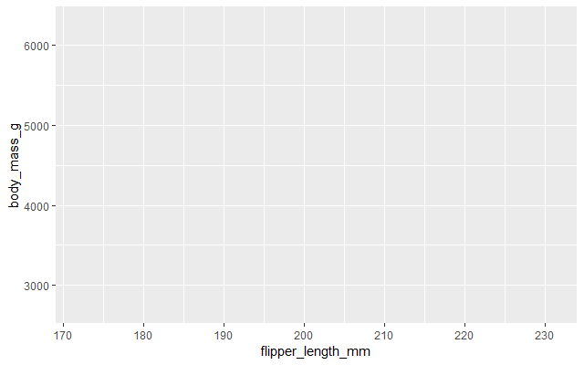

Layer 1 of 6 — each layer is drawn on top of the ones before it

Three of those steps are worth pausing on.

**Step 1** draws nothing — and still draws something. The axes are there, scaled to the data, because `ggplot()` was told which variables go where. The canvas knows its dimensions before anything is painted on it.

**Step 3** adds no data and no geometry. It maps `species` to colour, and one cloud becomes three. Nothing about the penguins changed; we only asked the plot to show a variable it had been ignoring.

**Step 4** then fits a line *per colour*, because the grouping introduced in step 3 is still in force. Layers inherit what came before them, which is what makes the grammar compose — and, occasionally, what makes it surprising.

## Amazing Fact

Now try the same trick on bill length and bill depth. Overall, penguins with longer bills have *shallower* bills — a clearly negative relationship. Within each species, the relationship is *positive*.

[figure not shown]

Figure 0.4: One negative trend, three positive ones: Simpson's paradox in the wild.

A grouping variable reversed the sign of a relationship. This is **Simpson's paradox**, and it is the reason a plot is not a decoration on top of an analysis. We meet it properly when we start comparing groups and building models.

## Your Turn: Build a plot

Again, the first Run installs `ggplot2` and the data in your browser and takes a moment.

R is not loaded yet

[interactive chart not shown]

Every layer is added with +. Order matters: later layers are drawn on top.

## Reading

[R for Data Science](https://r4ds.hadley.nz/) by Wickham, Çetinkaya-Rundel and Grolemund is the standard reference for everything in this section, free to read online. For graphics specifically, [ggplot2: Elegant Graphics for Data Analysis](https://ggplot2-book.org/) goes from the grammar to the details.

[^2]: See https://www.tidyverse.org/.
[^3]: Horst AM, Hill AP, Gorman KB (2020). *palmerpenguins: Palmer Archipelago (Antarctica) penguin data*. R package version 0.1.0. https://allisonhorst.github.io/palmerpenguins/. Data are released under CC-0 in accordance with the Palmer Station LTER data policy.